# Disease subtype discovery using multi-omics data integration

Ali Tabaraei

2024-01-31

Throughout this project, we will delve into various methodologies for uncovering molecular disease subtypes utilizing multi-omics data. The primary objective behind identifying disease subtypes is to categorize patients into cohesive groups based on similar clinical and/or molecular characteristics. By identifying these patient cohorts, we aim to enhance prognostic predictions, foreseeing the future health trajectory of individuals, and optimize treatment strategies tailored to each patient’s unique profile. This endeavor aligns closely with the principles of personalized (precision) medicine, which integrates genomic, environmental, and lifestyle factors into medical decision-making processes, leading to potential targets for therapeutic interventions.

# 1 Dataset and the packages

Before we dig into the algorithms and the implementations, we need to set up our coding environment and prepare the dataset of our interest, which will be performed in the following.

## 1.1 Installation of the packages

First of all, we set the default CRAN mirror to avoid errors while knitting the document to a HTML file. Then, we will install the required packages for our program and load them accordingly.

```r
options(repos = list(CRAN="http://cran.rstudio.com/"))
```

```r
if (!require("BiocManager", quietly = TRUE))
    install.packages("BiocManager")

# TCGA libraries
BiocManager::install("curatedTCGAData")
BiocManager::install("TCGAutils")
BiocManager::install("TCGAbiolinks")

# Other libraries
install.packages("SNFtool")
install.packages("NetPreProc")
install.packages("caret")
install.packages("cluster")
install.packages("mclustcomp")

# NEMO Library
install.packages("devtools")
devtools::install_github("Shamir-Lab/NEMO/NEMO")
```

```r
# TCGA libraries
library("curatedTCGAData")
library("TCGAutils")
library("TCGAbiolinks")

# Other libraries
library("SNFtool")
library("NetPreProc")
library("caret")
library("cluster")
library("mclustcomp")
```

## 1.2 Dataset Preparation

The project focuses on uncovering disease subtypes using a multi-omics dataset sourced from The Cancer Genome Atlas (TCGA) program [1]. TCGA represents a genomics initiative that contains over 11,000 cases spanning 33 tumor types, incorporating diverse biological data sources such as mRNA expression, miRNA expression, copy number values, DNA methylation, and protein expression.

Specifically, we utilize the `curatedTCGAData` [2] package for our analysis to work with the **Prostate adenocarcinoma dataset** (disease code “PRAD”), considering only **3 different omics data sources** (miRNA, mRNA, and protein expression data), as they were investigated by *The Cancer Genome Atlas Research Network* [3] and their integrative clustering model (called iCluster [4]).

We have now our 3 data sources stored in a `MultiAssayExperiment` object, which contains the miRNA, mRNA, and protein expression data respectively.

```r
PRAD_data
```

```
## A MultiAssayExperiment object of 3 listed
##  experiments with user-defined names and respective classes.
##  Containing an ExperimentList class object of length 3:
##  [1] PRAD_miRNASeqGene-20160128: SummarizedExperiment with 1046 rows and 547 columns
##  [2] PRAD_RNASeq2Gene-20160128: SummarizedExperiment with 20501 rows and 550 columns
##  [3] PRAD_RPPAArray-20160128: SummarizedExperiment with 195 rows and 352 columns
## Functionality:
##  experiments() - obtain the ExperimentList instance
##  colData() - the primary/phenotype DataFrame
##  sampleMap() - the sample coordination DataFrame
##  `$`, `[`, `[[` - extract colData columns, subset, or experiment
##  *Format() - convert into a long or wide DataFrame
##  assays() - convert ExperimentList to a SimpleList of matrices
##  exportClass() - save data to flat files
```

# 2 Preprocessing of the data

First, let’s create a function which enables us to easily print the dimensions of the `MultiAssayExperiment` or `list` objects during the preprocessing steps:

```r
# creating a function to print dimensions of MAE or matrix in preprocessing steps
printDims <- function(data, assays_list, step_type, text) {
  if (class(text) == "numeric") {
    cat("Preprocessing step ", text, " (", step_type, "):\n", sep="")
  }
  else {
    cat(text, " (", step_type, "):\n", sep="")
  }


  # print the dimensions of each assay separately
  for (i in 1:length(assays_list)) {
    assay <- assays_list[[i]]
    assay_name <- names(assays_list)[i]

    if (class(data) == "list") {
      nrows <- dim(data[[i]])[1]
      ncols <- dim(data[[i]])[2]
    }
    else {
      nrows <- nrow(assay)
      ncols <- ncol(assay)
    }

    cat("Assay '", assay_name, "' Dimensions: [", nrows, ", ", ncols, "]\n", sep="")
  }

  # print a separation line for better printing style
  if (step_type == "after") cat(rep("-", 40), "\n")
  else cat("\n")
}
```

Now, we can proceed with preprocessing steps. Several steps should be taken in order, which are specified in the following:

1. We aim to **include only samples of patients with a primary tumor type** (excluding metastases, which constitute abnormal masses) to ensure having a homogeneous group of samples. According to the TCGA barcode structure, we will select samples with “Primary Solid Tumors” which are identified by the code `01` in the *sample* part of the barcode.

   ```r
   # 1. selecting samples with primary solid tumors
   printDims(PRAD_data, assays(PRAD_data), "before", 1)
   ```

   ```
   ## Preprocessing step 1 (before):
   ## Assay 'PRAD_miRNASeqGene-20160128' Dimensions: [1046, 547]
   ## Assay 'PRAD_RNASeq2Gene-20160128' Dimensions: [20501, 550]
   ## Assay 'PRAD_RPPAArray-20160128' Dimensions: [195, 352]
   ```

   ```r
   primary <- TCGAutils::TCGAsampleSelect(colnames(PRAD_data), c("01"))
   PRAD_data <- PRAD_data[, primary, ]
   printDims(PRAD_data, assays(PRAD_data), "after", 1)
   ```

   ```
   ## Preprocessing step 1 (after):
   ## Assay 'PRAD_miRNASeqGene-20160128' Dimensions: [1046, 494]
   ## Assay 'PRAD_RNASeq2Gene-20160128' Dimensions: [20501, 497]
   ## Assay 'PRAD_RPPAArray-20160128' Dimensions: [195, 352]
   ## - - - - - - - - - - - - - - - - - - - - - - - - - - - - - - - - - - - - - - - -
   ```

2. We need to examine whether technical replicates are present and **exclude any duplicated patient samples** if identified. To accomplish this, we can leverage the first 12 characters of the barcode to uniquely identify patients and subsequently filter out any duplicated samples associated with them.

   ```r
   # 2. checking for duplicated samples (none exists to be removed)
   cat("Preprocessing step 2:\n")
   ```

   ```
   ## Preprocessing step 2:
   ```

   ```r
   check_rep <- anyReplicated(PRAD_data)
   print(check_rep)
   ```

   ```
   ## PRAD_miRNASeqGene-20160128  PRAD_RNASeq2Gene-20160128
   ##                      FALSE                      FALSE
   ##    PRAD_RPPAArray-20160128
   ##                      FALSE
   ```

   ```r
   cat("There is no duplicated data to be removed\n")
   ```

   ```
   ## There is no duplicated data to be removed
   ```

   ```r
   cat(rep("-", 40), "\n")
   ```

3. There are two primary tissue preparation methods to store and preserve samples: FFPE (Formalin-Fixed Paraffin-Embedded), and freezing the samples. Due to the superior preservation of DNA and RNA molecules in frozen tissues, **samples preserved using the FFPE technique will be excluded** from further analysis.

   ```r
   # 3. removing FFPE collected samples
   printDims(PRAD_data, assays(PRAD_data), "before", 3)
   ```

   ```
   ## Preprocessing step 3 (before):
   ## Assay 'PRAD_miRNASeqGene-20160128' Dimensions: [1046, 494]
   ## Assay 'PRAD_RNASeq2Gene-20160128' Dimensions: [20501, 497]
   ## Assay 'PRAD_RPPAArray-20160128' Dimensions: [195, 352]
   ```

   ```r
   no_ffpe <- which(as.data.frame(colData(PRAD_data))$patient.samples.sample.is_ffpe == "no")
   PRAD_data <- PRAD_data[, no_ffpe, ]
   printDims(PRAD_data, assays(PRAD_data), "after", 3)
   ```

   ```
   ## Preprocessing step 3 (after):
   ## Assay 'PRAD_miRNASeqGene-20160128' Dimensions: [1046, 494]
   ## Assay 'PRAD_RNASeq2Gene-20160128' Dimensions: [20501, 497]
   ## Assay 'PRAD_RPPAArray-20160128' Dimensions: [195, 352]
   ## - - - - - - - - - - - - - - - - - - - - - - - - - - - - - - - - - - - - - - - -
   ```

4. Not every sample has all the omics data sources available. Therefore, we will limit our analysis to **samples that possess data for all the considered omics**.

   ```r
   # 4. select samples having all data sources available
   printDims(PRAD_data, assays(PRAD_data), "before", 4)
   ```

   ```
   ## Preprocessing step 4 (before):
   ## Assay 'PRAD_miRNASeqGene-20160128' Dimensions: [1046, 494]
   ## Assay 'PRAD_RNASeq2Gene-20160128' Dimensions: [20501, 497]
   ## Assay 'PRAD_RPPAArray-20160128' Dimensions: [195, 352]
   ```

   ```r
   PRAD_data <- intersectColumns(PRAD_data)
   printDims(PRAD_data, assays(PRAD_data), "after", 4)
   ```

   ```
   ## Preprocessing step 4 (after):
   ## Assay 'PRAD_miRNASeqGene-20160128' Dimensions: [1046, 348]
   ## Assay 'PRAD_RNASeq2Gene-20160128' Dimensions: [20501, 348]
   ## Assay 'PRAD_RPPAArray-20160128' Dimensions: [195, 348]
   ## - - - - - - - - - - - - - - - - - - - - - - - - - - - - - - - - - - - - - - - -
   ```

5. In the majority of bioinformatics data sources, features are typically arranged in rows, with samples represented as columns in the matrix. To align with conventional data science practices, we will transpose the matrices, **ensuring to have features in columns and samples in rows**.

   ```r
   # 5. transpose the assays to have features in cols and samples in rows
   printDims(PRAD_data, assays(PRAD_data), "before", 5)
   ```

   ```
   ## Preprocessing step 5 (before):
   ## Assay 'PRAD_miRNASeqGene-20160128' Dimensions: [1046, 348]
   ## Assay 'PRAD_RNASeq2Gene-20160128' Dimensions: [20501, 348]
   ## Assay 'PRAD_RPPAArray-20160128' Dimensions: [195, 348]
   ```

   ```r
   PRAD_matrix <- assays(PRAD_data)
   PRAD_matrix <- lapply(PRAD_matrix, FUN=t)
   printDims(PRAD_matrix, assays(PRAD_data), "after", 5)
   ```

   ```
   ## Preprocessing step 5 (after):
   ## Assay 'PRAD_miRNASeqGene-20160128' Dimensions: [348, 1046]
   ## Assay 'PRAD_RNASeq2Gene-20160128' Dimensions: [348, 20501]
   ## Assay 'PRAD_RPPAArray-20160128' Dimensions: [348, 195]
   ## - - - - - - - - - - - - - - - - - - - - - - - - - - - - - - - - - - - - - - - -
   ```

6. Before performing any type of machine learning algorithm, the **data should be free of possible existing missing values**. In this study, since only a negligible number of features in proteomics data contain missing values, we will directly remove those features rather than using permutation techniques.

   ```r
   # 6. remove the features containing missing data
   printDims(PRAD_matrix, assays(PRAD_data), "before", 6)
   ```

   ```
   ## Preprocessing step 6 (before):
   ## Assay 'PRAD_miRNASeqGene-20160128' Dimensions: [348, 1046]
   ## Assay 'PRAD_RNASeq2Gene-20160128' Dimensions: [348, 20501]
   ## Assay 'PRAD_RPPAArray-20160128' Dimensions: [348, 195]
   ```

   ```r
   for (i in 1:length(PRAD_matrix)) {
     PRAD_matrix[[i]] <- PRAD_matrix[[i]][, colSums(is.na(PRAD_matrix[[i]])) == 0]
   }
   printDims(PRAD_matrix, assays(PRAD_data), "after", 6)
   ```

   ```
   ## Preprocessing step 6 (after):
   ## Assay 'PRAD_miRNASeqGene-20160128' Dimensions: [348, 1046]
   ## Assay 'PRAD_RNASeq2Gene-20160128' Dimensions: [348, 20501]
   ## Assay 'PRAD_RPPAArray-20160128' Dimensions: [348, 186]
   ## - - - - - - - - - - - - - - - - - - - - - - - - - - - - - - - - - - - - - - - -
   ```

7. In the field of Bioinformatics, the existence of a higher number of features than samples can pose challenges for machine learning techniques, and it may lead to poor performance particularly when numerous features with significant contributions have low variance. In this study, as it is asked by the project description, we will only **select the top 100 features having highest variance from each data source**. However, this strategy overlooks feature interactions and redundancy, introducing potential limitations.

   ```r
   # 7. select top 100 highest variance features
   printDims(PRAD_matrix, assays(PRAD_data), "before", 7)
   ```

   ```
   ## Preprocessing step 7 (before):
   ## Assay 'PRAD_miRNASeqGene-20160128' Dimensions: [348, 1046]
   ## Assay 'PRAD_RNASeq2Gene-20160128' Dimensions: [348, 20501]
   ## Assay 'PRAD_RPPAArray-20160128' Dimensions: [348, 186]
   ```

     # sort and keep the top 100 highest variance features
     vars <- apply(PRAD_matrix[[i]], 2, var)
     idx <- sort(vars, index.return=TRUE, decreasing = TRUE)$ix
     PRAD_matrix[[i]] <- PRAD_matrix[[i]][, idx[1:n_features]]
   }
   ```

   ```
   ## Removed 418 features from PRAD_miRNASeqGene-20160128
   ## Removed 1334 features from PRAD_RNASeq2Gene-20160128
   ## Removed 0 features from PRAD_RPPAArray-20160128
   ```

   ```r
   cat("\n")
   ```

   ```r
   printDims(PRAD_matrix, assays(PRAD_data), "after", 7)
   ```

   ```
   ## Preprocessing step 7 (after):
   ## Assay 'PRAD_miRNASeqGene-20160128' Dimensions: [348, 100]
   ## Assay 'PRAD_RNASeq2Gene-20160128' Dimensions: [348, 100]
   ## Assay 'PRAD_RPPAArray-20160128' Dimensions: [348, 100]
   ## - - - - - - - - - - - - - - - - - - - - - - - - - - - - - - - - - - - - - - - -
   ```

8. Since the omics data have been acquired with diverse measurements in various units or scales, we can perform standardization techniques to facilitate a meaningful comparison and analysis. To achieve this, we will use **z-score normalization**, which guarantees a standard normal distribution with a mean of 0 and a standard deviation of 1. The formula is $z = \frac{{x - \mu}}{{\sigma}}$, where $\mu$ represents the mean and $\sigma$ corresponds to the standard deviation.

   ```r
   # 8. apply z-score normalization
   cat("Preprocessing step 8:\n")
   ```

   ```
   ## Preprocessing step 8:
   ```

   ```r
   zscore <- function(data) {
     zscore_vec <- function(x) { return ((x - mean(x)) / sd(x)) }
     data <- apply(data, 2, zscore_vec)
     return(data)
   }
   PRAD_matrix <- lapply(PRAD_matrix, zscore)
   cat("Normalization of the data has been performed successfully\n")
   ```

   ```
   ## Normalization of the data has been performed successfully
   ```

   ```r
   cat(rep("-", 40), "\n")
   ```

9. The final step in our preprocessing pipeline is to **clean the barcodes to retain only the first 12 characters** for each individual, i.e. “Project-TSS-Participant”.

   ```r
   # 9. retain first 12 characters of individual barcodes
   cat("Preprocessing step 9:\n")
   ```

   ```
   ## Preprocessing step 9:
   ```

   ```r
   for(i in 1:length(PRAD_matrix)) {
     rownames(PRAD_matrix[[i]]) <- substr(rownames(PRAD_matrix[[i]]), 1, 12)
   }
   cat("Barcode names have been cleaned successfully\n")
   ```

   ```
   ## Barcode names have been cleaned successfully
   ```

   ```r
   cat(rep("-", 40), "\n")
   ```

# 3 Downloading the disease subtypes

In order to prepare the disease subtypes, we take the following steps in order:

1. First, we **download the disease subtypes** having the `PRAD` code as cancer type, using the `TCGAbiolinks` package.

   ```r
   # downloading the disease subtypes
   subtypes <- as.data.frame(TCGAbiolinks::PanCancerAtlas_subtypes())
   subtypes <- subtypes[subtypes$cancer.type == "PRAD", ]
   cat("Total number of subtypes: ", dim(subtypes)[1])
   ```

   ```
   ## Total number of subtypes:  333
   ```

   ```r
   head(subtypes)
   ```

   ```
   ##        pan.samplesID cancer.type Subtype_mRNA Subtype_DNAmeth Subtype_protein
   ## 5978 TCGA-HC-7818-01        PRAD            3               4              NA
   ## 5979 TCGA-HC-7077-01        PRAD            2               1               1
   ## 5980 TCGA-G9-6356-01        PRAD            3               3               1
   ## 5981 TCGA-HC-7213-01        PRAD            2               3               1
   ## 5982 TCGA-KK-A6E1-01        PRAD            2               3              NA
   ## 5983 TCGA-VP-A872-01        PRAD            2               3              NA
   ##      Subtype_miRNA Subtype_CNA Subtype_Integrative Subtype_other
   ## 5978             1       Quiet                   3         1-ERG
   ## 5979             2   Some_SCNA                   2         1-ERG
   ## 5980             1   Some_SCNA                   3         1-ERG
   ## 5981             6   More_SCNA                   3         1-ERG
   ## 5982             3   More_SCNA                   2         1-ERG
   ## 5983             6   More_SCNA                   2         1-ERG
   ##      Subtype_Selected
   ## 5978       PRAD.1-ERG
   ## 5979       PRAD.1-ERG
   ## 5980       PRAD.1-ERG
   ## 5981       PRAD.1-ERG
   ## 5982       PRAD.1-ERG
   ## 5983       PRAD.1-ERG
   ```

2. At the second step, we select and **keep only the samples of patients with a primary tumor type**.

   ```r
   cat('Dimenstions of DataFrame (before): ', dim(subtypes), "\n")
   ```

   ```
   ## Dimenstions of DataFrame (before):  333 10
   ```

   ```r
   subtypes <- subtypes[TCGAutils::TCGAsampleSelect(subtypes$pan.samplesID, "01"), ]
   cat('Dimenstions of DataFrame (after): ', dim(subtypes), "\n")
   ```

   ```
   ## Dimenstions of DataFrame (after):  333 10
   ```

   ```r
   cat("All the samples have a primary tumor type", "\n")
   ```

   ```
   ## All the samples have a primary tumor type
   ```

   ```r
   cat(rep("-", 40), "\n")
   ```

3. At this step, we **retain only the first 12 characters of the barcode** for each individual existing in the multi-omics dataset, setting that as the row names of the DataFrame.

   ```r
   subtypes <- subtypes[substr(subtypes$pan.samplesID,1,12) %in% rownames(PRAD_matrix[[1]]), ]
   rownames(subtypes) <- substr(subtypes$pan.samplesID, 1, 12)
   head(subtypes)
   ```

   ```
   ##                pan.samplesID cancer.type Subtype_mRNA Subtype_DNAmeth
   ## TCGA-HC-7077 TCGA-HC-7077-01        PRAD            2               1
   ## TCGA-G9-6356 TCGA-G9-6356-01        PRAD            3               3
   ## TCGA-HC-7213 TCGA-HC-7213-01        PRAD            2               3
   ## TCGA-KK-A6E1 TCGA-KK-A6E1-01        PRAD            2               3
   ## TCGA-CH-5741 TCGA-CH-5741-01        PRAD            2               3
   ## TCGA-J4-A6M7 TCGA-J4-A6M7-01        PRAD            2               3
   ##              Subtype_protein Subtype_miRNA Subtype_CNA Subtype_Integrative
   ## TCGA-HC-7077               1             2   Some_SCNA                   2
   ## TCGA-G9-6356               1             1   Some_SCNA                   3
   ## TCGA-HC-7213               1             6   More_SCNA                   3
   ## TCGA-KK-A6E1              NA             3   More_SCNA                   2
   ## TCGA-CH-5741               1             3   Some_SCNA                   2
   ## TCGA-J4-A6M7              NA             2       Quiet                   2
   ##              Subtype_other Subtype_Selected
   ## TCGA-HC-7077         1-ERG       PRAD.1-ERG
   ## TCGA-G9-6356         1-ERG       PRAD.1-ERG
   ## TCGA-HC-7213         1-ERG       PRAD.1-ERG
   ## TCGA-KK-A6E1         1-ERG       PRAD.1-ERG
   ## TCGA-CH-5741         1-ERG       PRAD.1-ERG
   ## TCGA-J4-A6M7         1-ERG       PRAD.1-ERG
   ```

# 4 Checking the ordering of the samples

Now, we check that the patients in multi-omics dataset and subtypes are in the **same order**. This is a vital step in our implementation to avoid further errors.

```r
# put the subtypes in the same order of multi-omics dataset barcodes
subtypes <- subtypes[rownames(PRAD_matrix[[1]]),]
cat("Total number of subtypes: ", dim(subtypes)[1])
```

```
## Total number of subtypes:  348
```

```r
# create a DataFrame comparing the barcodes of subtypes and multi-omics together
compare_df <- as.data.frame(cbind(rownames(subtypes), rownames(PRAD_matrix[[1]])))
names(compare_df) <- c("Subtypes", "MultiOmics")
rownames(compare_df) <- compare_df$MultiOmics

# add an "Exists" column, denoting if the barcode from multi-omics dataset exists in subtypes
compare_df$Exists <- compare_df$Subtypes == compare_df$MultiOmics
head(compare_df); tail(compare_df)
```

```
##                  Subtypes   MultiOmics Exists
## TCGA-2A-A8VL TCGA-2A-A8VL TCGA-2A-A8VL   TRUE
## TCGA-2A-A8VO TCGA-2A-A8VO TCGA-2A-A8VO   TRUE
## TCGA-2A-A8VT TCGA-2A-A8VT TCGA-2A-A8VT   TRUE
## TCGA-2A-A8VV TCGA-2A-A8VV TCGA-2A-A8VV   TRUE
## TCGA-2A-A8W1 TCGA-2A-A8W1 TCGA-2A-A8W1   TRUE
## TCGA-2A-A8W3 TCGA-2A-A8W3 TCGA-2A-A8W3   TRUE
```

```
##              Subtypes   MultiOmics Exists
## TCGA-YL-A9WY    NA.94 TCGA-YL-A9WY  FALSE
## TCGA-ZG-A9LB    NA.95 TCGA-ZG-A9LB  FALSE
## TCGA-TP-A8TV    NA.96 TCGA-TP-A8TV  FALSE
## TCGA-V1-A9OX    NA.97 TCGA-V1-A9OX  FALSE
## TCGA-YL-A9WX    NA.98 TCGA-YL-A9WX  FALSE
## TCGA-ZG-A9L9    NA.99 TCGA-ZG-A9L9  FALSE
```

Keep in mind that not every subtype is present in the subset of samples that possess all the specified omics data sources. Using the `Exists` column which we created in the previous step, we can compare the barcodes of subtypes and multi-omics dataset together, and **eliminate the samples which do not have an associated disease subtype**.

```r
selected_barcodes <- rownames(compare_df[compare_df$Exists, ])
printDims(PRAD_matrix, assays(PRAD_data), "before", "Multi-Omics Dataset")
```

```
## Multi-Omics Dataset (before):
## Assay 'PRAD_miRNASeqGene-20160128' Dimensions: [348, 100]
## Assay 'PRAD_RNASeq2Gene-20160128' Dimensions: [348, 100]
## Assay 'PRAD_RPPAArray-20160128' Dimensions: [348, 100]
```

```r
subtypes <- subtypes[selected_barcodes, ]
PRAD_matrix <- lapply(PRAD_matrix, function(assay) assay[selected_barcodes, ])
printDims(PRAD_matrix, assays(PRAD_data), "after", "Multi-Omics Dataset")
```

```
## Multi-Omics Dataset (after):
## Assay 'PRAD_miRNASeqGene-20160128' Dimensions: [248, 100]
## Assay 'PRAD_RNASeq2Gene-20160128' Dimensions: [248, 100]
## Assay 'PRAD_RPPAArray-20160128' Dimensions: [248, 100]
## - - - - - - - - - - - - - - - - - - - - - - - - - - - - - - - - - - - - - - - -
```

Below, you can see the resulting number of samples for each subtype, where the subtypes reported by `Subtype_Integrative` column is the one containing the iCluster molecular subtypes:

```r
subtypes_count_df <- as.data.frame(table(subtypes$Subtype_Integrative))
names(subtypes_count_df) <- c("iCluster.Subtype", "Count")
subtypes_count_df
```

```
##   iCluster.Subtype Count
## 1                1    60
## 2                2    83
## 3                3   105
```

# 5 Data Integration

Several different strategies have been studied by the literature to mix and combine the different multi-omics data sources. In the following, the implementation of 3 of these strategies have been provided:

## 5.1 Integrating the data using SNF

Recent advancements in data collection allow cost-effective gathering of diverse genome-wide data. **Similarity Network Fusion (SNF)** [5], efficiently combines these data types, creating a comprehensive view of diseases or biological processes. SNF constructs individual networks for each data type (e.g., mRNA expression, DNA methylation) and merges them into a unified network. This approach is exemplified in the analysis of patient cohorts, where SNF computes and fuses patient similarity networks from each data type, providing a concise yet comprehensive understanding of underlying biological mechanisms. The algorithm is described in the following:

   $$\begin{equation}
   \label{eq:local_kernel}
   S^{(s)}(i,j) =
   \begin{cases}
   \frac{W^{(s)}(i,j)}{\sum_{k \in N_i} W^{(s)}(i,k)} & \text{, if
   $j \in N_i$}\\
   0 & , \text{otherwise}\\
   \end{cases}
   \end{equation}$$
4. Through an iterative process, given $s$ data sources (here $s = 3$), $s$ different $W$, $S$ and $P$ matrices are constructed where similarities are diffused through the $P$s until convergence (matrices $P$ become similar). To achieve this, for each different $s$, $P$ is updated by using $S$ from the same data source but $P$ from a different view, and vice versa. In the simplest case, when $s=2$, we have $P_t^{(s)}$ that refers to $P$ matrices for data $s \in \{ 1,2\}$ at time $t$. In this case, the following recursive updating formulas describe the diffusion process:

   $$\begin{equation}
   \label{eq:update}
   \begin{aligned}
   P^{(1)}_{t+1}=S^{(1)} \times P^{(2)}_{t} \times S^{(1)\top} \\
   P^{(2)}_{t+1}=S^{(2)} \times P^{(1)}_{t} \times S^{(2)\top}
   \end{aligned}
   \end{equation}$$
5. The final *integrated* matrix $P^{(c)}$ is computed by averaging as below:

   $$\begin{equation}
   \label{eq:consensus}
   P^{(c)} = \frac{1}{s} \sum_{k=1}^{s} P^{(k)}
   \end{equation}$$

The implementation of the multi-omics data integration using SNF (derived from CRAN `SNFtool` package) is provided below, where $t = 20$ is the number of iterations, and $K = 20$ is the number of neighbors to be considered for the local similarity matrix $S^{(s)}$ computation.

```r
#
n_neighbours <- 20
n_iters <- 20

# compute affinity matrices using the scaled exponential euclidean distance
W <- list();
for(i in 1:length(PRAD_matrix)){
    distance <- (dist2(as.matrix(PRAD_matrix[[i]]), as.matrix(PRAD_matrix[[i]])))^(1/2);
    W[[i]] <- affinityMatrix(distance);
}

# multi-omics data integration using SNF
P <- SNF(W, K=n_neighbours, t=n_iters)
```

## 5.2 Integrating the data using simple averaging

This is the most trivial multi-omics data integration strategy that can be utilized to fuse the different similarity matrices from each data source into one, by performing a simple averaging of the matrices as:

$$W_{\text{avg}}(i,j) =
\frac{1}{|\text{{data sources}}|} \sum_{s \in \text{{data sources}}}
W^{(s)}(i,j)$$

```r
W_avg <- Reduce(`+`, W) / length(W)

# Checking if it works correctly as expected
W_avg[1,1] == (W[[1]][1, 1] + W[[2]][1, 1] + W[[3]][1, 1])/length(W)
```

```
## [1] TRUE
```

## 5.3 Integrating the data using NEMO (OPTIONAL)

Although the implementation of `NEMO` [6] clustering has been assigned to the students working as a `GROUP`, to satisfy my own curiosity, I will explore this technique as well. `NEMO` [6], standing for *NEighborhood based Multi-Omics clustering*, is a novel algorithm for multi-omics clustering. NEMO can be applied to partial datasets in which some patients have data for only a subset of the omics, without performing data imputation.

Since the `nemo.affinity.graph()` function takes as input a matrix with features in rows and samples in columns, we need to transpose the input to this function. Below, the computation of the NEMO affinity graph is provided:

```r
PRAD_matrix_transposed <- lapply(PRAD_matrix, FUN=t)
AF_NEMO <- NEMO::nemo.affinity.graph(PRAD_matrix_transposed, k=n_neighbours)
```

# 6 Clustering (disease subtype discovery)

We will now proceed with the implementation of a clustering algorithm to identify the disease subtypes, which we can later compare these obtained clusters with the disease subtypes investigated by iCluster.

## 6.1 PAM clustering

PAM [7] clustering algorithm, short for *partition around medoids*, aims to identify a set of candidate medoids which represent the center of the clusters, minimizing the average dissimilarity of objects to their closest selected medoid by iteratively selecting and swapping medoids. The process continues until no further improvement can be made, and is divided into two main phases:

### 6.1.1 Build Phase

We explicitly set $k$ as the number of clusters to be found, and we attempt to find the candidate medoids to be stored in set $S$. We initialize $S$ by adding an object with minimal distances to all other objects. Then, to add other $k - 1$ elements to $S$, we perform the following steps iteratively for finding each candidate medoid:

- Let’s set $O$ as the set of *all* objects, $S$ as the *selected* objects, and $U = O - S$ as *unselected* objects. Considering a new candidate $i \in U$, for all the other unselected objects $j \in U - \{ i \}$, first compute the **distance between** $j$ and the **closest medoid** currently in $S$, namely $D_j$, and then compute the **distance between** $j$ and the **new candidate** $i$, namely $d(i,j)$.
- The clustering may benefit from the new candidate $i$ if $d(i,j) < Dj$, so will aggregate the contribution of all $j$ into a total gain computed as $g_i = \sum_{j \in U} max \{(D_j - d(i,j)), 0 \}$. Consequently, we will choose the candidate $i$ maximizing $g_i$, and update the $S := S \cup \{i \}$ and $U := U - \{i \}$ accordingly.
- We repeat until $k$ candidates have been selected.

### 6.1.2 Swap Phase

It attempts to improve the quality of the selected candidates by swapping objects between $S$ and $U$. For each pair $(i, h) \in S \times U$ (where $i \in S$ and $h \in U$) to be considered for swapping, we perform the following steps:

- We swap $i$ and $h$, as $h$ becomes a candidate and $i$ is unselected.
- For each object $j \in U - \{h\}$ (all except the swapped objects), if $d(j, i) > D_{j}$ (where $D_{j}$ is the dissimilarity between $j$ and the **closest** object in $S$), then we compute the contribution $K_{jih} = min\{d(j,h) - D_{j}, 0\}$. Otherwise, if $d(j, i) = D_{j}$, then, $K_{jih} = min\{d(j,h), E_{j}\} - D_{j}$ (where $E_{j}$ is the dissimilarity between $j$ and the **second closest** object in $S$) is computed.
- We compute the total result of the swap as $T_{ih} = \sum\{ K_{jih} | j \in U\}$, and we select the pair $(i, h)$ minimizing $T_{ih}$.
- If $T_{ih} > 0$, the algorithm halts since the objective value cannot be decreased. Otherwise, if $T_{ih} < 0$, the swap is performed, $D_{j}$ and $E_{j}$ are updated, and we jump to the first step of the “Swap” phase.

### 6.1.3 Implementation

The implementation of the algorithm is provided below:

```r
pam_clustering <- function(matrix, k) {
  # compute the distance, normalized within [0, 1]
  distance_matrix <- 1 - NetPreProc::Max.Min.norm(matrix)

  # compute the PAM clustering for the given distance matrix, setting diss=TRUE
  result <- pam(distance_matrix, k=k, diss=TRUE)
  return (result)
}
```

In this study, we will set the number of clusters to be found by PAM algorithm as $k = 3$, which is equal to the number of disease subtypes found by iCluster.

```r
k <- length(unique(subtypes_count_df$iCluster.Subtype))
cat("The number of clusters: ", k, "\n")
```

```
## The number of clusters:  3
```

The algorithm will be performed on the following similarity matrices:

1. Similarity matrices obtained from each single data source, which are stored in `W`
2. Integrated matrix obtained from averaging over matrices, which is stored in `W_avg`
3. Integrated matrix obtained from SNF, which is stored in `P`
4. Integrated matrix obtained from NEMO, which is stored in `AF_NEMO` (OPTIONAL)

```r
PAM_miRNA <- pam_clustering(W[[1]], k)
PAM_mRNA <- pam_clustering(W[[2]], k)
PAM_protein <- pam_clustering(W[[3]], k)
PAM_W_avg <- pam_clustering(W_avg, k)
PAM_SNF <- pam_clustering(P, k)
PAM_AF_NEMO <- pam_clustering(AF_NEMO, k)
```

## 6.2 NEMO clustering (OPTIONAL)

*NEMO* provides the possibility of performing clustering using another approach called *Spectral Clustering* [8]. We use the function `nemo.clustering()` to test this approach as below:

```r
NEMO_clustering <- NEMO::nemo.clustering(PRAD_matrix_transposed, num.clusters=k, num.neighbors=n_neighbours)
```

## 6.3 Spectral clustering (OPTIONAL)

```r
Spectral_clustering <- SNFtool::spectralClustering(P, k)
names(Spectral_clustering) <- colnames(P)
```

# 7 Results and comparison

Now that we have different clustering results obtained from PAM, NEMO, and Spectral Clustering, we can proceed with comparing the aforementioned results with the disease subtypes reported by iCluster.

## 7.1 Evalation Metrics

In the literature, several evaluation metrics can be found to compare the clustering results [9], and using `mclustcomp` R package we can access 24 different scores. Here, we will consider 3 of the most used techniques, which are described in the following:

### 7.1.1 Rand Index (RI)

Given the clusters $C_1$ and $C_2$, this metric can be computed by counting the pair of objects in the same cluster in both $C_1$ and $C_2$ (denoted as $n_{11}$), along with the pair of objects in different clusters both in $C_1$ and $C_2$ (denoted as $n_{11}$), with respect to the all possible pairs. As a result, this metric is bounded within $[0, 1]$, representing similar clusters when $R(C_1, C_2)$ approaches $1$, and dissimilar clusters when near zero.

$$\begin{equation}
R(C_1, C_2) = \frac{2(n_{11} + n_{00})}{n(n-1)}
\end{equation}$$

### 7.1.2 Adjusted Rand Index (ARI)

The Adjusted Rand Index (ARI) is utilized to measure the similarity between two data clusterings. It is an enhancement over the Rand Index as a basic measure of similarity between two clusterings, overcoming its disadvantage of being sensitive to chance. The ARI takes into account the fact that two random partitions of a dataset should not assume a constant value, and it adjusts the Rand Index to account for this possibility. ARI ranges within $[-0.5, 1]$, where it represents identical clustering on values near $1$, and indicates independent clusterings when approaching negative values.

### 7.1.3 Normalized Mutual Information (NMI)

The *Mutual Information* (MI) measures how much we can reduce uncertainty about an element’s cluster when we already know its cluster in another clustering. It is defined as below, where $P(i,j)= \frac{|C_{1i} \cap C_{2j}|}{n}$ is the probability that an element belongs to cluster $C_i \in C_1$ and cluster $C_j \in C_2$:

$$\begin{equation}
MI(C_1, C_2) = \sum_{i=1}^{k} \sum_{j=1}^{l} P(i,j) log_{2}
\frac{P(i,j)}{P(i)P(j)}
\end{equation}$$

However, since it is not upper-bounded, it would be difficult to interpret the obtained results, so we use a normalized version of MI to bound it in the range $[0, 1]$ (maximum NMI for identical clusterings), which is *Normalized Mutual Information* (NMI). It is defined as below, where $H(C_1)$ and $H(C_2)$ are the corresponding entropies of the clusterings $C_1$ and $C_2$:

$$\begin{equation}
NMI(C_1, C_2) = \frac{MI(C_1, C_2)}{\sqrt{H(C_1) H(C_2)}}
\end{equation}$$

## 7.2 Comparing the clustering results

In this project, we covered PAM clustering algorithm over a set of different matrices, and also investigated the NEMO and spectral clustering. Now, in this final section, we will report the results of the clustering compared to the ones reported by iCluster.

```r
# convert the disease subtypes to numeric values
unique_subtypes <- unique(subtypes$Subtype_Integrative)
labels <- as.numeric(factor(subtypes$Subtype_Integrative, levels=unique_subtypes))

# compute the RI, ARI, and NMI metrics over all clustering results
types <- c("rand", "adjrand", "nmi1")

# PAM clustering metrics
metrics.PAM_miRNA <- mclustcomp(PAM_miRNA$clustering, labels, types=types)
metrics.PAM_mRNA <- mclustcomp(PAM_mRNA$clustering, labels, types=types)
metrics.PAM_protein <- mclustcomp(PAM_protein$clustering, labels, types=types)
metrics.PAM_W_avg <- mclustcomp(PAM_W_avg$clustering, labels, types=types)
metrics.PAM_SNF <- mclustcomp(PAM_SNF$clustering, labels, types=types)
metrics.PAM_AF_NEMO <- mclustcomp(PAM_AF_NEMO$clustering, labels, types=types)

# NEMO clustering metric
metrics.NEMO_clustering <- mclustcomp(NEMO_clustering, labels, types=types)

# Spectral clustering metric
metrics.Spectral_clustering <- mclustcomp(Spectral_clustering, labels, types=types)
```

- As the second step, we prepare a DataFrame to report all the results in a table.

```r
# Create a list of dataframes
results_df <- rbind(
  t(metrics.PAM_miRNA$scores),
  t(metrics.PAM_mRNA$scores),
  t(metrics.PAM_protein$scores),
  t(metrics.PAM_W_avg$scores),
  t(metrics.PAM_SNF$scores),
  t(metrics.PAM_AF_NEMO$scores),
  t(metrics.NEMO_clustering$scores),
  t(metrics.Spectral_clustering$scores)
)

# Correct the ordering of columns as expected
colnames(results_df) <- as.list(metrics.PAM_miRNA$types)
results_df <- results_df[, c("rand", "adjrand", "nmi1")]

# correct the corresponding rowname/colnames
colnames(results_df) <- c("RI", "ARI", "NMI")
rownames(results_df) <- list(
  "PAM_miRNA",
  "PAM_mRNA",
  "PAM_protein",
  "PAM_W_avg",
  "PAM_SNF",
  "PAM_AF_NEMO",
  "NEMO",
  "Spectral"
)

# print the results
results_df
```

```
##                    RI         ARI        NMI
## PAM_miRNA   0.5424122 0.024669347 0.02763638
## PAM_mRNA    0.5574964 0.037660032 0.05320068
## PAM_protein 0.5523704 0.007886092 0.01965598
## PAM_W_avg   0.5598145 0.023650868 0.04030343
## PAM_SNF     0.6316769 0.179466272 0.15674451
## PAM_AF_NEMO 0.5617735 0.032536154 0.05438288
## NEMO        0.3803056 0.014593726 0.06891715
## Spectral    0.6051326 0.119098119 0.11723454
```

- Now, We will report the results of the clustering for each different clustering method.

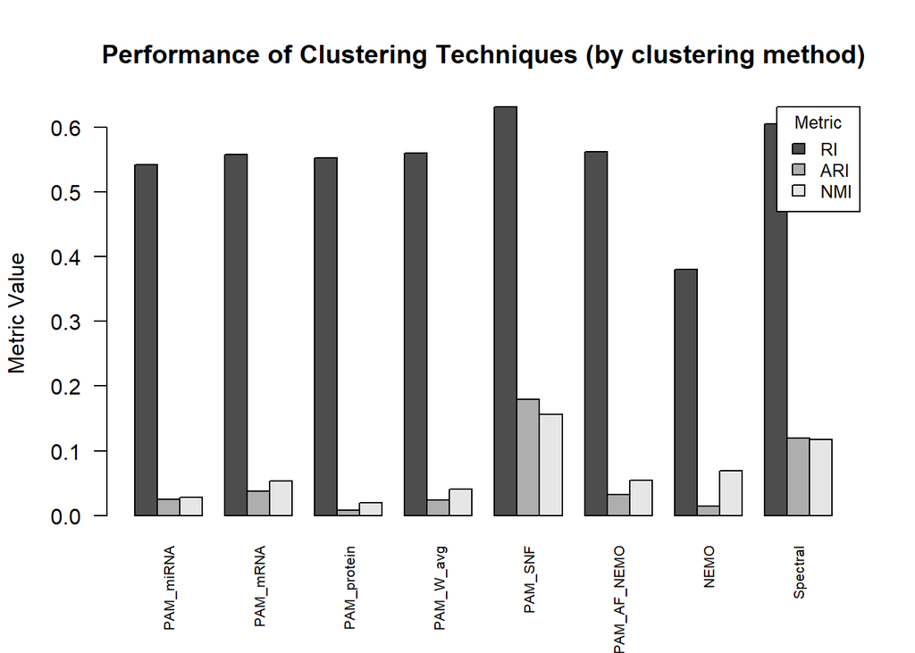

```r
barplot(
  t(results_df),
  beside = TRUE,
  main = "Performance of Clustering Techniques (by clustering method)",
  ylab = "Metric Value",
  cex.names = 0.65,
  las = 2,
  legend.text = TRUE,
  args.legend = list(title="Metric", x="topright", bty="c", cex=0.8)
)
```

- Finally, we can provide another plot representing each metric separately for different algorithms.

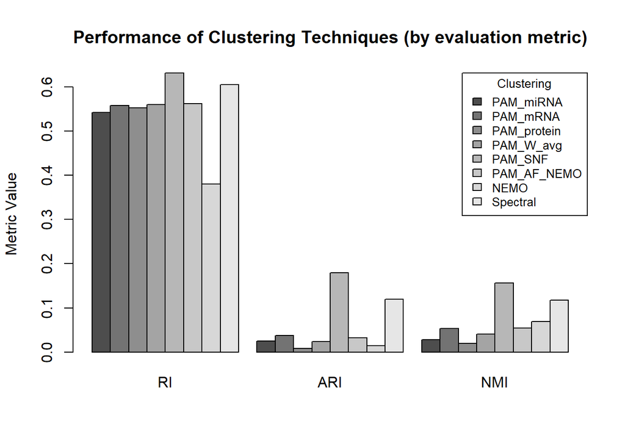

```r
barplot(
  results_df,
  beside = TRUE,
  main = "Performance of Clustering Techniques (by evaluation metric)",
  ylab = "Metric Value",
  legend.text = TRUE,
  args.legend = list(title="Clustering", x="topright", bty="c", cex=0.8)
)
```

# 8 Session Info

Below, you can find overall details about the version of R, the operating system, loaded packages, and other relevant information using the `sessionInfo()`, where a summary of the session’s details are provided.

[session information not shown]

# 9 References

[1]

C. Hutter and J. C. Zenklusen, “The cancer genome atlas: Creating lasting value beyond its data,” *Cell*, vol. 173, no. 2, pp. 283–285, 2018.

[2]

M. Ramos *et al.*, “Multiomic integration of public oncology databases in bioconductor,” *JCO Clinical Cancer Informatics*, vol. 1, pp. 958–971, 2020.

[3]

A. Abeshouse *et al.*, “The molecular taxonomy of primary prostate cancer,” *Cell*, vol. 163, no. 4, pp. 1011–1025, 2015.

[4]

R. Shen, A. B. Olshen, and M. Ladanyi, “Integrative clustering of multiple genomic data types using a joint latent variable model with application to breast and lung cancer subtype analysis,” *Bioinformatics*, vol. 25, no. 22, pp. 2906–2912, 2009.

[5]

B. Wang *et al.*, “Similarity network fusion for aggregating data types on a genomic scale,” *Nature methods*, vol. 11, no. 3, pp. 333–337, 2014.

[6]

N. Rappoport and R. Shamir, “NEMO: Cancer subtyping by integration of partial multi-omic data,” *Bioinformatics*, vol. 35, no. 18, pp. 3348–3356, 2019.

[7]

“Partitioning around medoids (program PAM),” in *Finding groups in data*, John Wiley & Sons, Ltd, 1990, pp. 68–125. doi: https://doi.org/10.1002/9780470316801.ch2.

[8]

U. Von Luxburg, “A tutorial on spectral clustering,” *Statistics and computing*, vol. 17, pp. 395–416, 2007.

[9]

S. Wagner and D. Wagner, *Comparing clusterings: An overview*. Universität Karlsruhe, Fakultät für Informatik Karlsruhe, 2007.